# Titanic Analysis

Ting Han Gan

19/07/2021

## Introduction

Objective: Predicting survival of Titanic passengers To do this, I will explroe the data and perform pre-processing techniques to make the data set suitable for the model fitting that follows.

A quick graph analysis of suitable attributes to the response target variable (Survived) is also performed to also identify key variables that impact the probability of survival rate through inspection.

Implementation of classication models using each of the following techniques are also used to determine the feature importance within the dataset. - Decision Tree - Bagging - Boosting - Random Forest

## Data Preparation

```r
# Libraries used in this project
library(ggplot2)
library(tree)
library(e1071)
library(data.table)
library(caret)
library(adabag)
library(rpart)
library(randomForest)

# Reading in data
train = read.csv("train.csv")
test = read.csv("test.csv")

# Checking the structure of the data
str(train)
```

```
## 'data.frame':    891 obs. of  12 variables:
##  $ PassengerId: int  1 2 3 4 5 6 7 8 9 10 ...
##  $ Survived   : int  0 1 1 1 0 0 0 0 1 1 ...
##  $ Pclass     : int  3 1 3 1 3 3 1 3 3 2 ...
##  $ Name       : Factor w/ 891 levels "Abbing, Mr. Anthony",..: 109 191 358 277 16 559 520 629 417 581 ...
##  $ Sex        : Factor w/ 2 levels "female","male": 2 1 1 1 2 2 2 2 1 1 ...
##  $ Age        : num  22 38 26 35 35 NA 54 2 27 14 ...
##  $ SibSp      : int  1 1 0 1 0 0 0 3 0 1 ...
##  $ Parch      : int  0 0 0 0 0 0 0 1 2 0 ...
##  $ Ticket     : Factor w/ 681 levels "110152","110413",..: 524 597 670 50 473 276 86 396 345 133 ...
##  $ Fare       : num  7.25 71.28 7.92 53.1 8.05 ...
##  $ Cabin      : Factor w/ 148 levels "","A10","A14",..: 1 83 1 57 1 1 131 1 1 1 ...
##  $ Embarked   : Factor w/ 4 levels "","C","Q","S": 4 2 4 4 4 3 4 4 4 2 ...
```

```r
# Converting to factor
train$Survived = as.factor(train$Survived)
train$Sex = as.factor(train$Sex)

# Identifying those variables that have any NA values or missing values
colSums(is.na(train))
```

```
## PassengerId    Survived      Pclass        Name         Sex         Age
##           0           0           0           0           0         177
##       SibSp       Parch      Ticket        Fare       Cabin    Embarked
##           0           0           0           0           0           0
```

```r
colSums(train=="")
```

```
## PassengerId    Survived      Pclass        Name         Sex         Age
##           0           0           0           0           0          NA
##       SibSp       Parch      Ticket        Fare       Cabin    Embarked
##           0           0           0           0         687           2
```

From looking at the dataset, we can see that there are a lot of NA values within the variable “Age”. Thus, we would first need to clean and tidy up the data before proceeding.

I have decided to replace the NA values with the mean of their corresponding group of “Pclass” attribute. This was decided due to the fact that it seemed more of a “closer” susbstitute then simply imputing the values with either mean or median.

```r
for (i in which(sapply(train, is.numeric))) {
  for (j in which(is.na(train[, i]))) {
    train[j, i] <- mean(train[train[, "Pclass"] == train[j, "Pclass"], i],  na.rm = TRUE)
  }
}

# Test class also seem to have some NA values
for (i in which(sapply(test, is.numeric))) {
  for (j in which(is.na(test[, i]))) {
    test[j, i] <- mean(test[test[, "Pclass"] == test[j, "Pclass"], i],  na.rm = TRUE)
  }
}
```

In terms of the cells that consist of empty strings, it would be unreasonable to replace 687 values in the attribute “Cabin” as the data only contains 891 rows.

However, for the “Embarked” attribute I have decided to replace the values with to the most occurring value, “S”.

```r
table(train$Embarked)
```

```
##
##       C   Q   S
##   2 168  77 644
```

```r
train$Embarked[train$Embarked==""]="S"
train$Embarked = as.factor(train$Embarked)
train$Embarked = droplevels(train$Embarked)
attach(train)
```

## Graph Analysis

Investigating the relationship of attributes towards survival

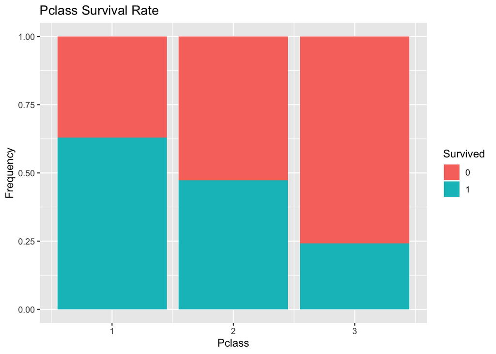

```r
ggplot(data=train, aes(x=Pclass, fill=Survived)) +
  geom_bar(stat="count", position="fill") +
  ylab("Frequency") + ggtitle("Pclass Survival Rate")
```

From the graph above, 1st class passengers seem to have on average a higher survival rate than 3rd class passengers.

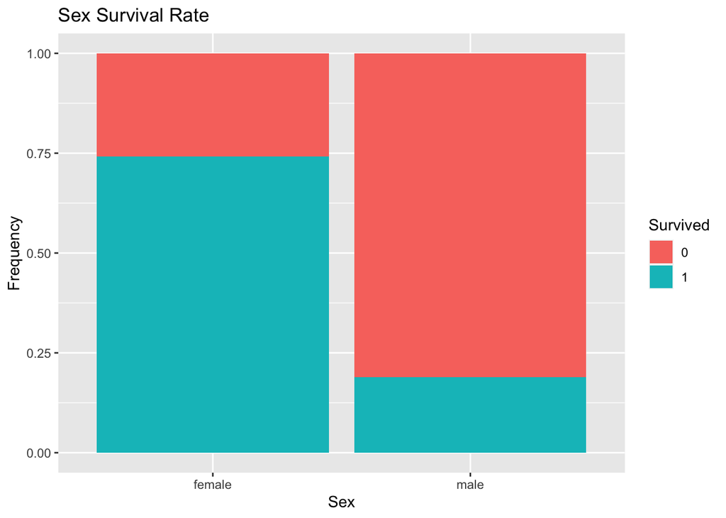

```r
ggplot(data=train, aes(x=Sex, fill=Survived)) +
  geom_bar(stat="count", position="fill") +
  ylab("Frequency") + ggtitle("Sex Survival Rate")
```

From the graph above, female on average had a higher survival rate than males.

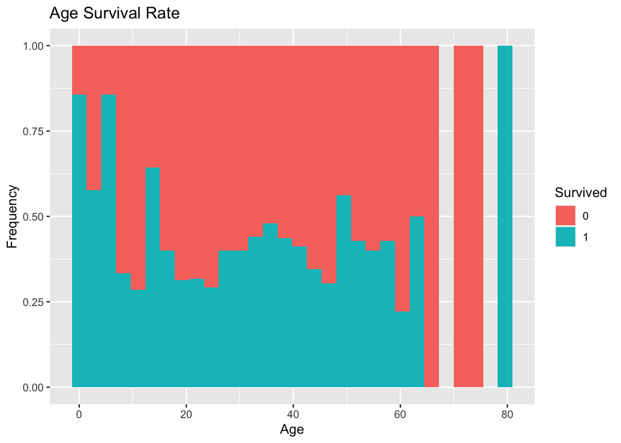

```r
ggplot(data=train, aes(x=Age, fill=Survived)) +
  geom_histogram(position="fill") +
  ylab("Frequency") + ggtitle("Age Survival Rate")
```

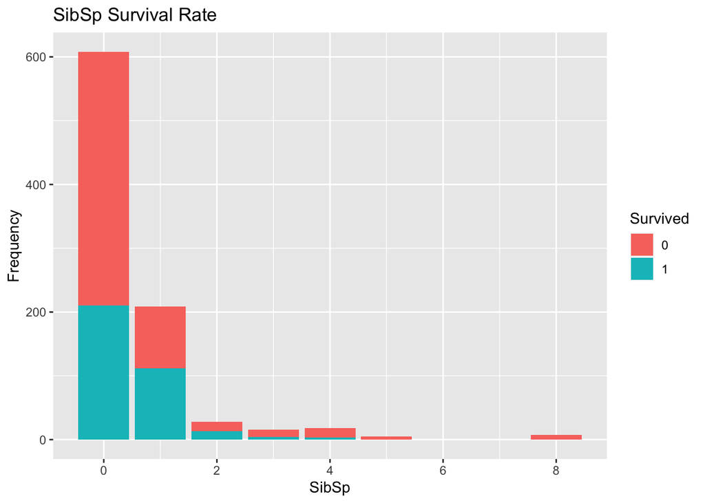

```r
ggplot(data=train, aes(x=SibSp, fill=Survived)) +
  geom_bar() +
  ylab("Frequency") + ggtitle("SibSp Survival Rate")
```

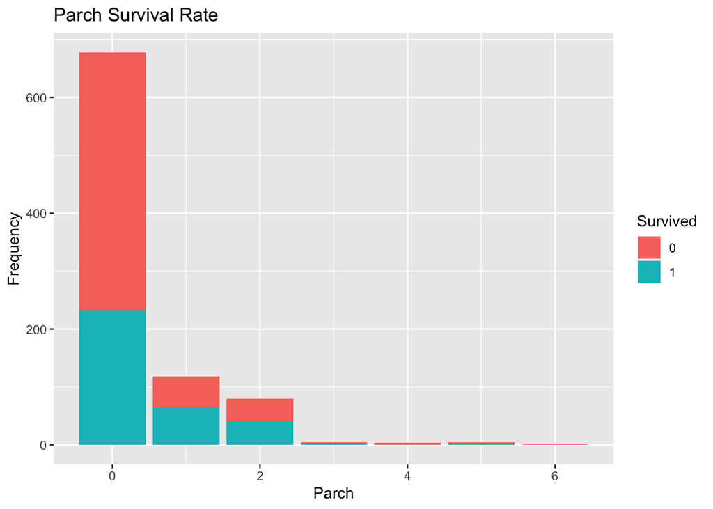

```r
ggplot(data=train, aes(x=Parch, fill=Survived)) +
  geom_bar() +
  ylab("Frequency") + ggtitle("Parch Survival Rate")
```

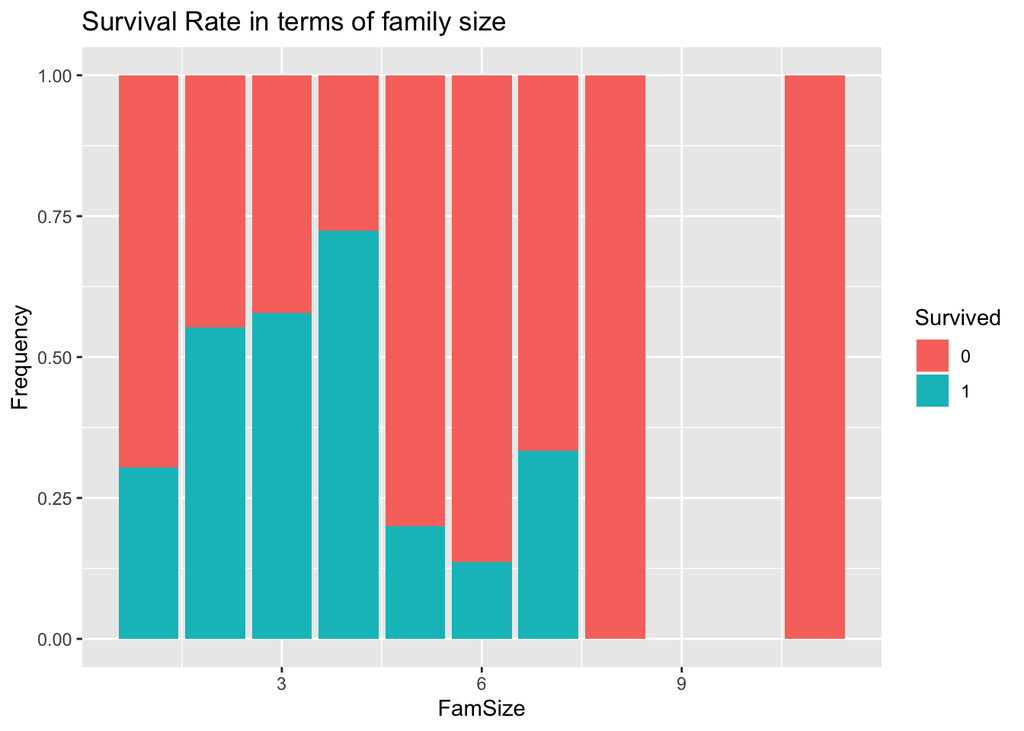

```r
# Since SibSp and Parch were similar in content, we could further analyse them by combining them together to estimate the "Family" size each passenger travelled with.
train$FamSize = as.integer(train$SibSp + train$Parch + 1)
ggplot(data=train, aes(x=FamSize, fill=Survived)) +
  geom_bar(stat="count", position="fill") +
  ylab("Frequency") + ggtitle("Survival Rate in terms of family size")
```

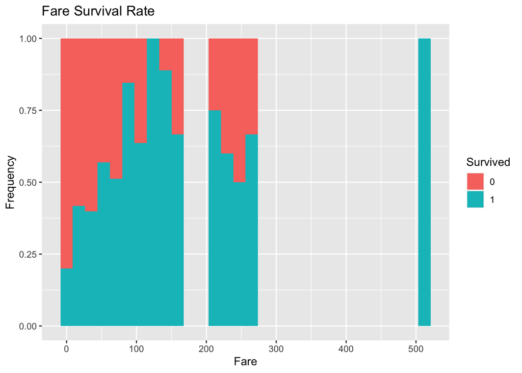

```r
ggplot(data=train, aes(x=Fare, fill=Survived)) +
  geom_histogram(position="fill") +
  ylab("Frequency") + ggtitle("Fare Survival Rate")
```

This attribute can be considred to be similar to Pclass attribute, however this one is not too conclusive to be able to draw any conclusions from.

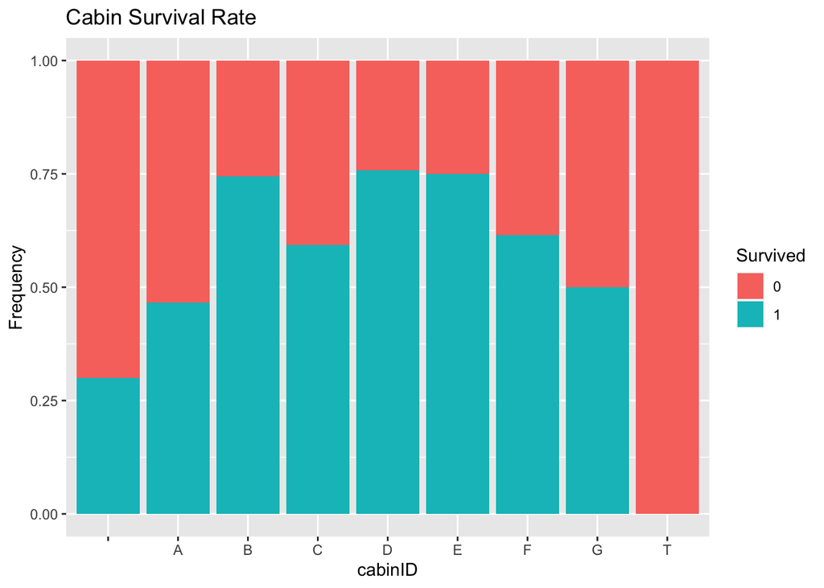

```r
train$cabinID = substr(train$Cabin, 1, 1)
ggplot(train, aes(x=cabinID, fill=Survived)) +
  geom_histogram(stat="count", position="fill") +
  ylab("Frequency") + ggtitle("Cabin Survival Rate")
```

Even though there was not too many cabin data that was gathered, it is still interesting to see that those in cabin B, D & E had a higher survival rate than A, G or T.

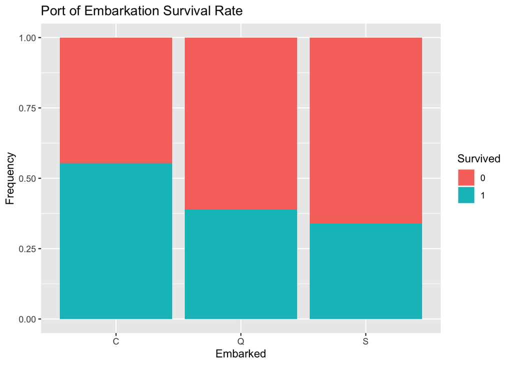

```r
ggplot(data=train, aes(x=Embarked, fill=Survived)) +
  geom_bar(position="fill") +
  ylab("Frequency") + ggtitle("Port of Embarkation Survival Rate")
```

This is also something interesting to look at, but boarding your transport at a certain time would not determine any survival rate in any way.

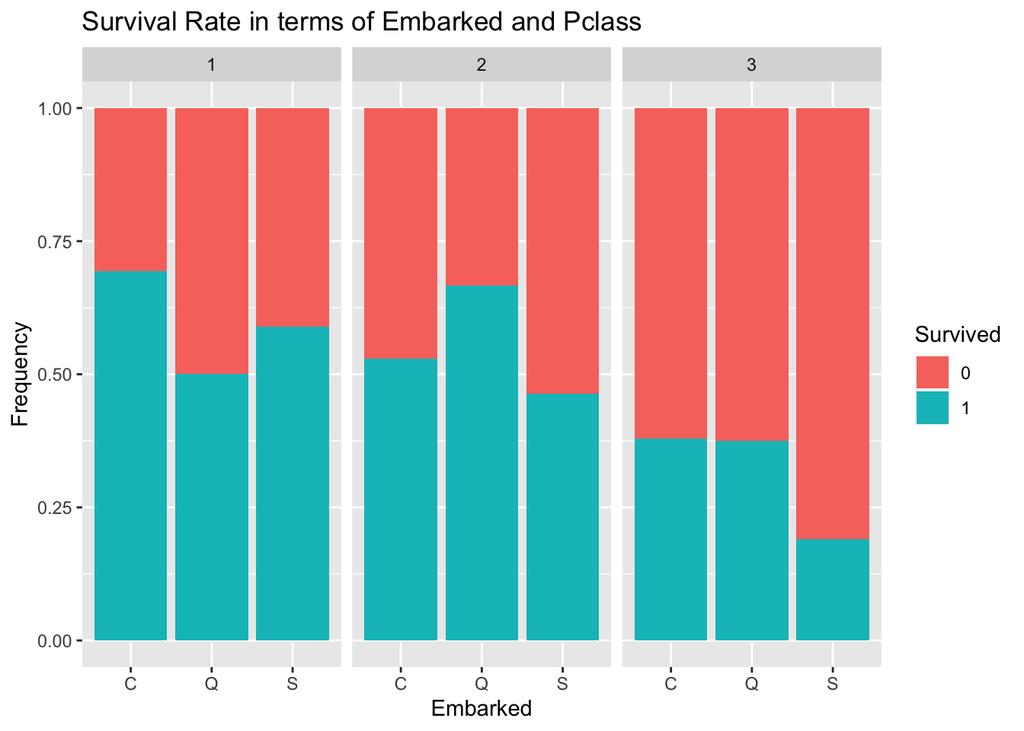

```r
ggplot(train, aes(x=Embarked, fill=Survived)) +
  geom_histogram(stat="count", position="fill")+
  facet_wrap(~Pclass) +
  ylab("Frequency") + ggtitle("Survival Rate in terms of Embarked and Pclass")
```

By creating the graph above, it also further proves that first class passengers havea higher survival rate on average more so than third class passengers.

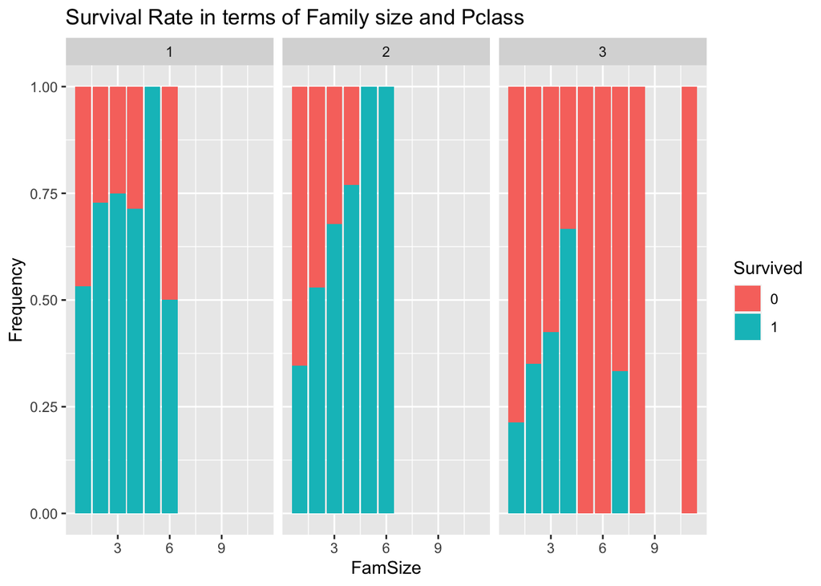

```r
ggplot(train, aes(x=FamSize, fill=Survived)) +
  geom_histogram(stat="count", position="fill")+
  facet_wrap(~Pclass) +
  ylab("Frequency") + ggtitle("Survival Rate in terms of Family size and Pclass")
```

The graph above also further adds to the point between survival rate and family size. Where on average, travelling with a family is safest in first or second class in comparison to travelling on third class.

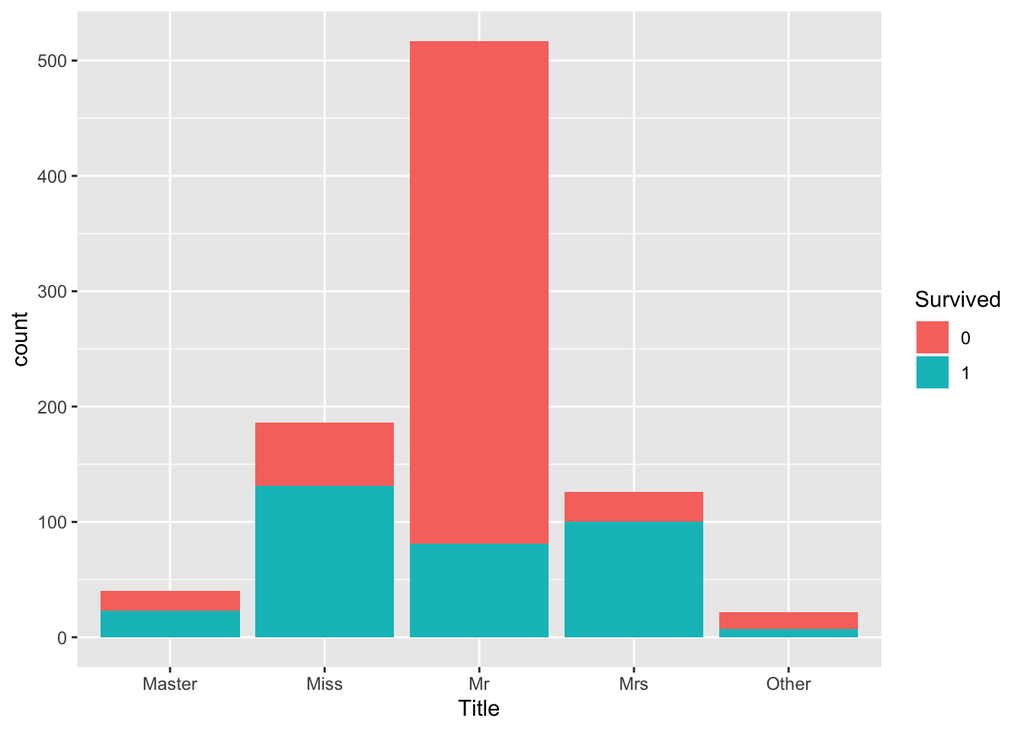

```r
# The title of each passengers name can also be extracted

train$Title <- gsub('(.*, )|(\\..*)', '', train$Name)

train$Title[train$Title == 'Mlle'] = 'Miss'
train$Title[train$Title == 'Ms'] = 'Miss'
train$Title[train$Title == 'Mme'] = 'Mrs'
train$Title[train$Title == 'Lady'] = 'Miss'
train$Title[train$Title == 'Dona'] = 'Miss'
Other <- c('Capt','Col','Don','Dr','Jonkheer','Major','Rev','Sir','the Countess')
train$Title[train$Title %in% Other] = "Other"

train$Title = as.factor(train$Title)

# Perform same function on test data set to be used later on
test$Title <- gsub('(.*, )|(\\..*)', '', test$Name)

test$Title[test$Title == 'Mlle'] = 'Miss'
test$Title[test$Title == 'Ms'] = 'Miss'
test$Title[test$Title == 'Mme'] = 'Mrs'
test$Title[test$Title == 'Lady'] = 'Miss'
test$Title[test$Title == 'Dona'] = 'Miss'
Other <- c('Capt','Col','Don','Dr','Jonkheer','Major','Rev','Sir','the Countess')
test$Title[test$Title %in% Other] = "Other"

test$Title = as.factor(test$Title)

ggplot(data=train, aes(x=Title, fill=Survived)) +
  geom_histogram(stat="count")
```

From the graph above, it can be seen that there are a lot more passengers that have a title Mr. compared to every other title.

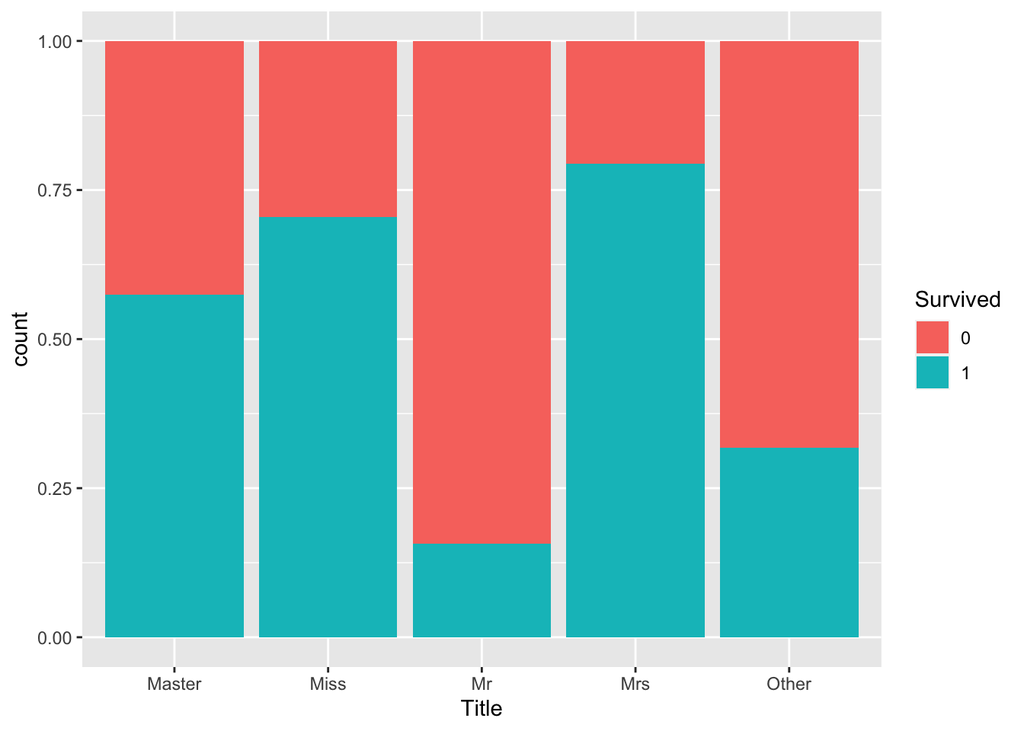

```r
ggplot(data=train, aes(x=Title, fill=Survived)) +
  geom_bar(position="fill")
```

However, as shown, there are a lot of passengers with the title Mr. that had a very low survival rate on Titanic, with Masters, Miss and Mrs having a higher survival rate.

## Classification Models

Creation of the models to predict survival rate

```r
# Only keep the numerical variables that are more significant
#(Pclass, Sex, Age, SibSp, Parch, Fare, Embarked, Title, Survived)
train_comp = train[,c(3,5,6,7,8,10,12,15,2)]

# Decision Tree *****
titanic.tree = tree(Survived ~., data = train_comp)

# Bagging *****
titanic.bag = bagging(Survived ~., data = train_comp, mfinal = 5)

# Boosting  *****
titanic.boost = boosting(Survived ~., data = train_comp, mfinal = 5)

# Random Forest  *****
titanic.rf = randomForest(Survived ~., data = train_comp, ntree=100)
```

## Overall Feature Importance

Summation of feature importance within the classifcation models used

```r
# Basic idea of model performance (tree)
summary(titanic.tree)
```

```
##
## Classification tree:
## tree(formula = Survived ~ ., data = train_comp)
## Variables actually used in tree construction:
## [1] "Title"  "Fare"   "Pclass"
## Number of terminal nodes:  5
## Residual mean deviance:  0.7997 = 708.5 / 886
## Misclassification error rate: 0.1684 = 150 / 891
```

```r
titanic.tree
```

```
## node), split, n, deviance, yval, (yprob)
##       * denotes terminal node
##
##  1) root 891 1187.00 0 ( 0.61616 0.38384 )
##    2) Title: Mr,Other 539  479.80 0 ( 0.83673 0.16327 )
##      4) Fare < 26.2688 399  259.90 0 ( 0.89975 0.10025 ) *
##      5) Fare > 26.2688 140  180.00 0 ( 0.65714 0.34286 ) *
##    3) Title: Master,Miss,Mrs 352  416.40 1 ( 0.27841 0.72159 )
##      6) Pclass < 2.5 180   71.47 1 ( 0.05000 0.95000 ) *
##      7) Pclass > 2.5 172  238.20 0 ( 0.51744 0.48256 )
##       14) Fare < 23.35 128  170.30 1 ( 0.38281 0.61719 ) *
##       15) Fare > 23.35 44   26.81 0 ( 0.90909 0.09091 ) *
```

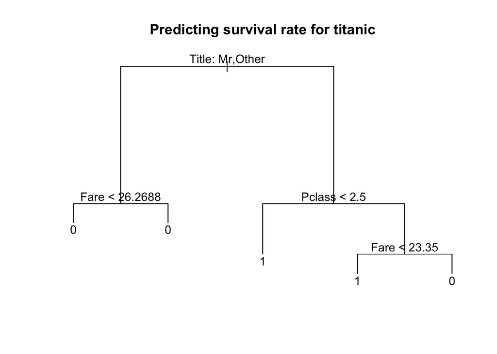

```r
plot(titanic.tree)
text(titanic.tree, pretty = 0) # Fix text
title("Predicting survival rate for titanic")
```

```r
## Overall Feature Importance
rf.importance = as.table(c(titanic.rf$importance[c(3),],0,0,titanic.rf$importance[c(5,1,2,4),],0))
class.var = cbind(titanic.bag$importance, titanic.boost$importance, rf.importance)
class.var = cbind(class.var, rowSums(class.var)) # Sums the row and combines to the dataframe
colnames(class.var) = c("Bagging", "Boosting", "Random Forest", "Total")
class.var = as.data.frame(class.var)
class.var = class.var[order(-class.var$Total),] # sort by descending order (Total)
class.var
```

```
##             Bagging   Boosting Random Forest      Total
## Title    61.6287934 38.6580920       0.00000 100.286885
## Pclass   15.5884028 19.8058513      32.18212  67.576376
## Sex       0.0000000  0.5539482      58.63248  59.186424
## Age       3.5813089 13.7889678      41.40775  58.778028
## Fare     14.6591332 23.4549726       0.00000  38.114106
## SibSp     2.8789980  2.3213709      17.76772  22.968087
## Parch     0.6945714  0.4250846      11.30908  12.428739
## Embarked  0.9687923  0.9917126       0.00000   1.960505
```

From the decision tree and table of the total sum of feature importance, it is clear that the attributes “Title”, “Pclass” and “Fare” are all significant in predicting the survival rate on titanic.

## Predicting Survival Rate using these Models

Creation of csv files to compare and measure the accuracy of the models

```r
# Predicting survival rate using decision tree model
tpredict = predict(titanic.tree, test, type = "class")
t.res = data.frame(test$PassengerId, tpredict)
names(t.res) = c("PassengerID", "Survived")
write.csv(t.res, file="tree.csv", row.names=FALSE)
```

```r
# Predicting survival rate using baggging model
bpredict = predict.bagging(titanic.bag, newdata = test)
bag.res = data.frame(test$PassengerId, bpredict$class)
names(bag.res) = c("PassengerID", "Survived")
write.csv(bag.res, file="bag.csv", row.names=FALSE)
```

```r
# Predicting survival rate using boosting model
bopredict = predict.boosting(titanic.boost, newdata = test)
boost.res = data.frame(test$PassengerId, bopredict$class)
names(boost.res) = c("PassengerID", "Survived")
write.csv(boost.res, file="boost.csv", row.names=FALSE)
```

```r
# Predicting survival rate using random forest model
rfpredict = predict(titanic.rf, test)
rf.res = data.frame(test$PassengerId, rfpredict)
names(rf.res) = c("PassengerID", "Survived")
write.csv(rf.res, file="rf.csv", row.names=FALSE)
```